# Intro to Maps in R

Wednesday, February 23, 2022 @ 03:35 PM

## What are Maps?

Maps in `R` are essentially very elaborate types of scatterplots.

Points are grouped so that they can be connected into shapes.

We can use ggplot2 to draw maps like we can any other plot.

Of course, there are some special functions to help us out!

There are many more `R` packages designed for mapmaking.

- maps /mapdata
- sf / ggspatial
- rnaturalearth
- tidygeocoder
- and more…

## Packages We Will Start With

```r
library(tidyverse)
```

We need `tidyverse` for data manipulation and plotting.

```r
library(maps)
```

Package containing geospatial data and functions for R.

```r
library(mapdata)
```

The mapdata package extends maps with more datasets.

Let’s go into the **maps** package and see what data is available! First look it up in the list of installed packages. We should also review [latitude and longitude](https://www.geographyrealm.com/zero-degrees-latitude-and-zero-degrees-longitude/).

## Some Mapping Basics

## Dataset `usa`

```r
usa <- map_data("usa")
head(usa, 2)
```

```
       long      lat group order region subregion
1 -101.4078 29.74224     1     1   main      <NA>
2 -101.3906 29.74224     1     2   main      <NA>
```

```r
str(usa)
```

```
'data.frame':   7243 obs. of  6 variables:
 $ long     : num  -101 -101 -101 -101 -101 ...
 $ lat      : num  29.7 29.7 29.7 29.6 29.6 ...
 $ group    : num  1 1 1 1 1 1 1 1 1 1 ...
 $ order    : int  1 2 3 4 5 6 7 8 9 10 ...
 $ region   : chr  "main" "main" "main" "main" ...
 $ subregion: chr  NA NA NA NA ...
```

## Regions

How many points does it take to outline a region (connect the dots)? The more irregular the shape, the more points needed.

```r
usa %>%
  count(region, group) # group is a numerical ID for region
```

```
              region group    n
1        long island     6  168
2       lopez island     8   17
3               main     1 6886
4          manhattan     4   16
5  martha's vineyard     2   36
6   nantucket island     3   30
7       orcas island     9   19
8    san juan island     7   17
9      staten island     5   10
10    whidbey island    10   44
```

## Mapping `usa`

Plot coordinates as paths in the x-y plane using [`geom_polygon`](https://ggplot2.tidyverse.org/reference/geom_polygon.html), with `x` = longitude and `y` = latitude.

Group divides the points into non-contiguous parts, like islands. As noted before, the variable `group` is a numerical identifier for `region` in the `usa` dataset.

Points are connected in the order they occur in the dataset, as we can double-check using the `order` variable.

Here I am choosing to specify the `aesthetics` in the `geometry`.

```r
ggplot() +
  geom_polygon(data = usa, aes(x = long, y = lat, group = group),
               color = "black",
               fill = "skyblue")
```

## Map of the USA

Does the map look odd plotted in the standard Cartesian plane?

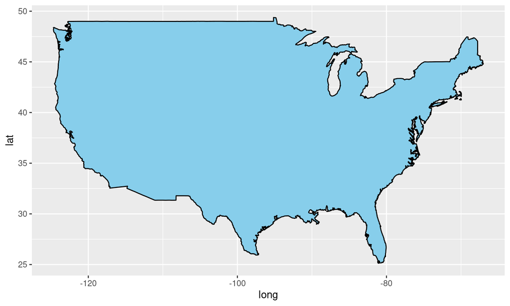

## USA from Space

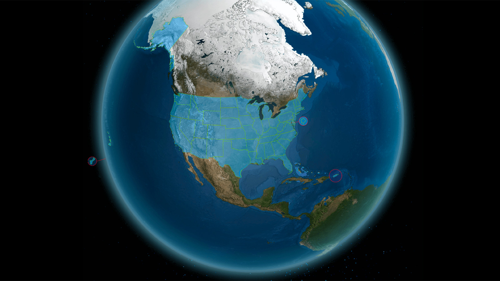

[NASA Has Space in All 50 States](https://www.nasa.gov/feature/jpl/nasa-has-space-in-all-50-states)

## Different Projections

The world is a sphere, but historically most maps are made flat. Different methods exist for trying to **project** a sphere on a plane without too much information distortion.

We will use the `coord_map()` function for this purpose. Two of the common options include…

- [Mercator](https://desktop.arcgis.com/en/arcmap/latest/map/projections/mercator.htm) projection method, the default in `coord_map()`
- [Mollweide](https://desktop.arcgis.com/en/arcmap/latest/map/projections/mollweide.htm) projection method

```r
ggplot(usa) +
  geom_polygon(aes(x = long, y = lat, group = group),
               color = "black",
               fill = "skyblue") +
  coord_map()
```

## Mercator

Has equally-spaced longitudes, wider latitudes moving away from the equator, preserves angles for navigation.

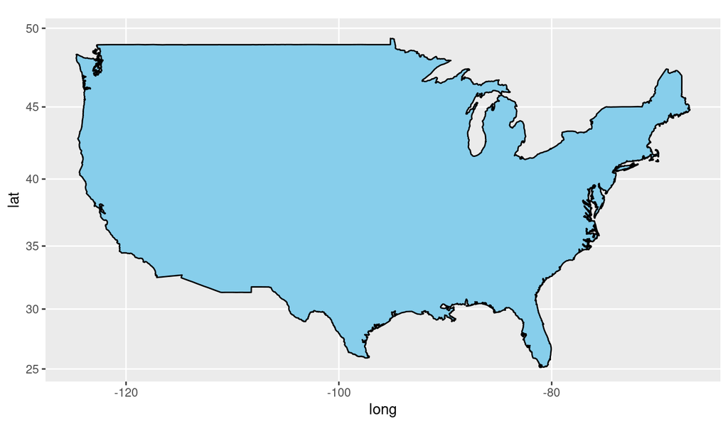

## Mollweide

Created by using `coord_map(projection = "mollweide")`. Preserves relative areas on the image relative to the globe.

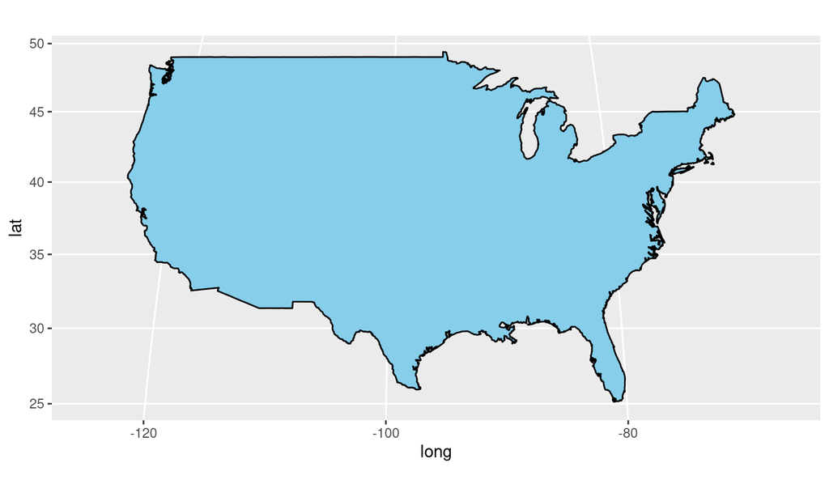

## Comparing Projections

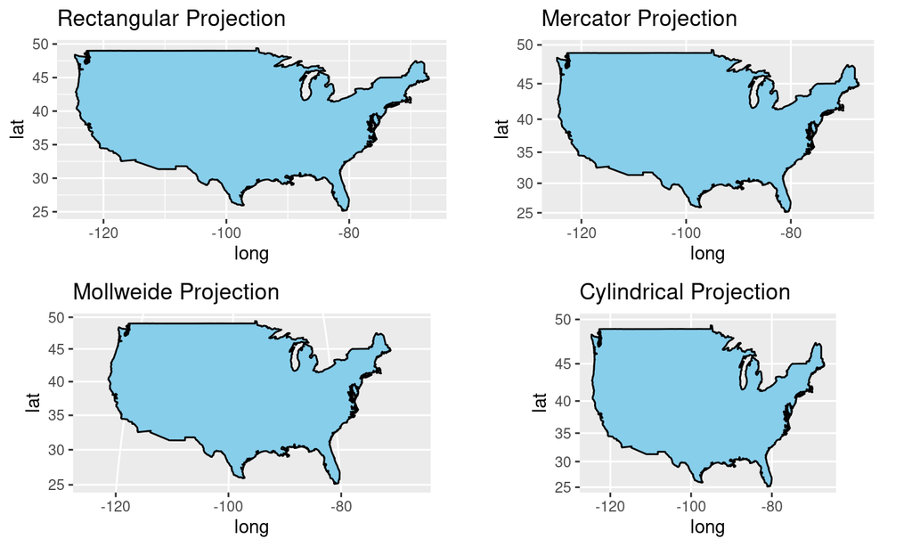

## Dataset `state`

```r
state <- map_data("state")
head(state, 12)
```

```
        long      lat group order  region subregion
1  -87.46201 30.38968     1     1 alabama      <NA>
2  -87.48493 30.37249     1     2 alabama      <NA>
3  -87.52503 30.37249     1     3 alabama      <NA>
4  -87.53076 30.33239     1     4 alabama      <NA>
5  -87.57087 30.32665     1     5 alabama      <NA>
6  -87.58806 30.32665     1     6 alabama      <NA>
7  -87.59379 30.30947     1     7 alabama      <NA>
8  -87.59379 30.28655     1     8 alabama      <NA>
9  -87.67400 30.27509     1     9 alabama      <NA>
10 -87.81152 30.25790     1    10 alabama      <NA>
11 -87.88026 30.24644     1    11 alabama      <NA>
12 -87.92037 30.24644     1    12 alabama      <NA>
```

## Mapping `state`

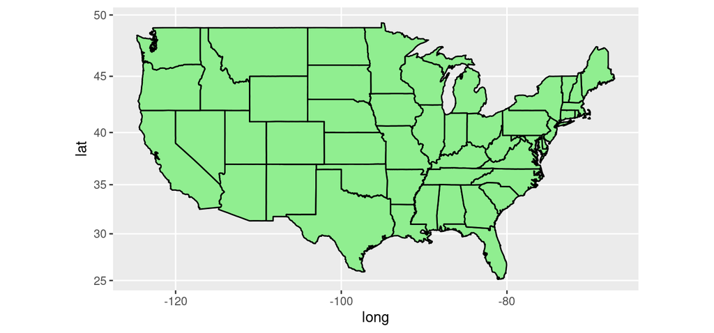

```r
ggplot() +
  geom_polygon(data = state, aes(x = long, y = lat, group = group),
               color = "black", fill = "lightgreen") +
  coord_map()
```

## Dataset `county`

```r
county <- map_data("county")
head(county, 10)
```

```
        long      lat group order  region subregion
1  -86.50517 32.34920     1     1 alabama   autauga
2  -86.53382 32.35493     1     2 alabama   autauga
3  -86.54527 32.36639     1     3 alabama   autauga
4  -86.55673 32.37785     1     4 alabama   autauga
5  -86.57966 32.38357     1     5 alabama   autauga
6  -86.59111 32.37785     1     6 alabama   autauga
7  -86.61403 32.38931     1     7 alabama   autauga
8  -86.61976 32.40649     1     8 alabama   autauga
9  -86.62549 32.41795     1     9 alabama   autauga
10 -86.63695 32.41795     1    10 alabama   autauga
```

## Mapping `county`

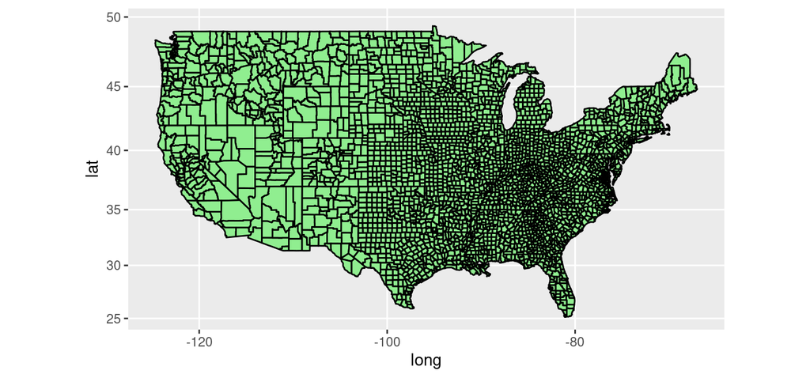

```r
ggplot() +
  geom_polygon(data = county, aes(x = long, y = lat, group = group),
               color = "black", fill = "lightgreen") +
  coord_map()
```

## Filtering `state` for NC

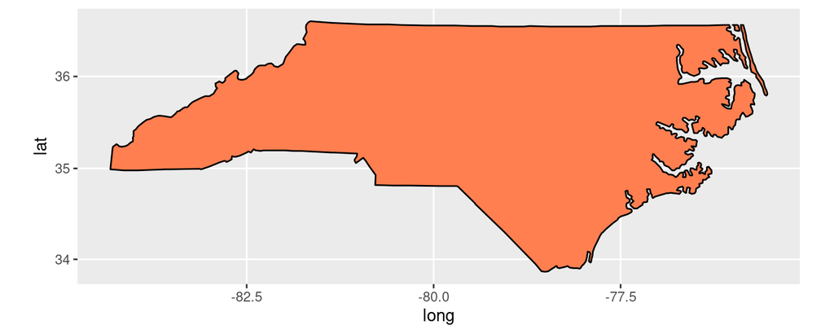

```r
filter(state, region == "north carolina") %>%
  ggplot() +
  geom_polygon(aes(x = long, y = lat, group = group),
               color = "black", fill = "coral") +
  coord_map()
```

## Filtering `county` for NC

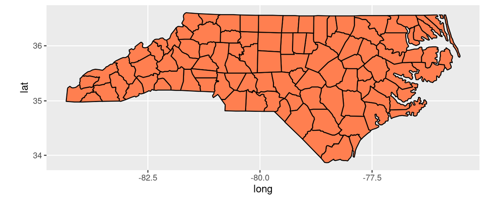

```r
filter(county, region == "north carolina") %>%
  ggplot() +
  geom_polygon(aes(x = long, y = lat, group = group),
               color = "black", fill = "coral") +
  coord_map()
```

## Filtering `world` for USA

```r
world <- map_data("world")
str(world)
```

```
'data.frame':   99338 obs. of  6 variables:
 $ long     : num  -69.9 -69.9 -69.9 -70 -70.1 ...
 $ lat      : num  12.5 12.4 12.4 12.5 12.5 ...
 $ group    : num  1 1 1 1 1 1 1 1 1 1 ...
 $ order    : int  1 2 3 4 5 6 7 8 9 10 ...
 $ region   : chr  "Aruba" "Aruba" "Aruba" "Aruba" ...
 $ subregion: chr  NA NA NA NA ...
```

```r
world_usa <- filter(map_data("world"), region == "USA")
```

## Mapping `world_usa`

Oops, there’s a bit of Alaska on the wrong side…

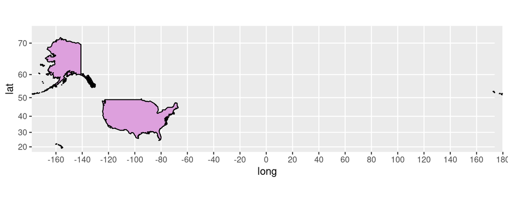

```r
ggplot(world_usa) +
  geom_polygon(aes(x = long, y = lat, group = group),
               color = "black", fill = "plum") +
  coord_map() +
  scale_x_continuous(breaks = seq(-160, 180, by = 20))
```

## Adjusting Our X-Axis

Change orientation from default to center at longitude 180.

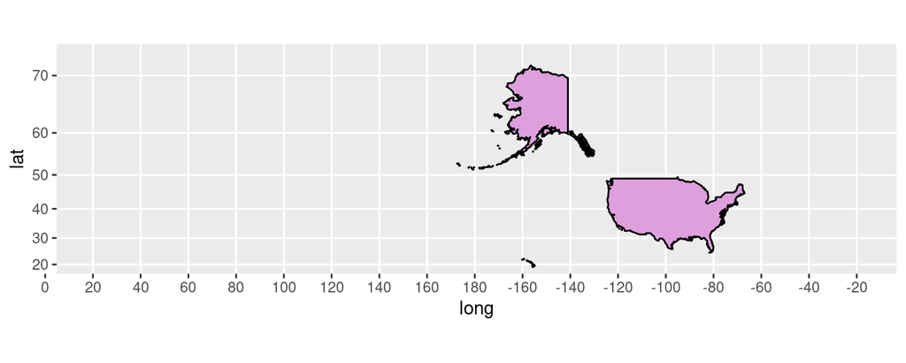

```r
ggplot(world_usa) +
  geom_polygon(aes(x = long, y = lat, group = group),
               color = "black", fill = "plum") +
  coord_map(orientation = c(90, 180, 0)) +
  scale_x_continuous(breaks = seq(-160, 180, by = 20))
```

## A Different Adjustment

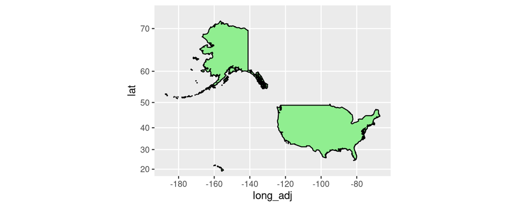

```r
world_usa %>%
  mutate(long_adj = ifelse(long > 0, long - 360, long)) %>%
  ggplot() +
  geom_polygon(aes(x = long_adj, y = lat, group = group),
               color = "black", fill = "lightgreen") +
  coord_map() +
  scale_x_continuous(breaks = seq(-200, 0, by = 20))
```

## The `mollweide` Projection

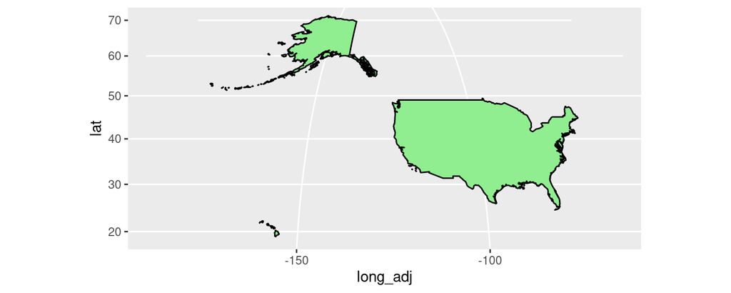

```r
worldmap <- world_usa %>%
  mutate(long_adj = ifelse(long > 0, long - 360, long)) %>%
  ggplot() +
  geom_polygon(aes(x = long_adj, y = lat, group = group),
               color = "black", fill = "lightgreen")
worldmap + coord_map(projection = "mollweide")
```

## The `ortho` Projection

We can store the basic map as an object and then add different customizations without repeating the basic mapping code. This is true for any ggplot2 plot.

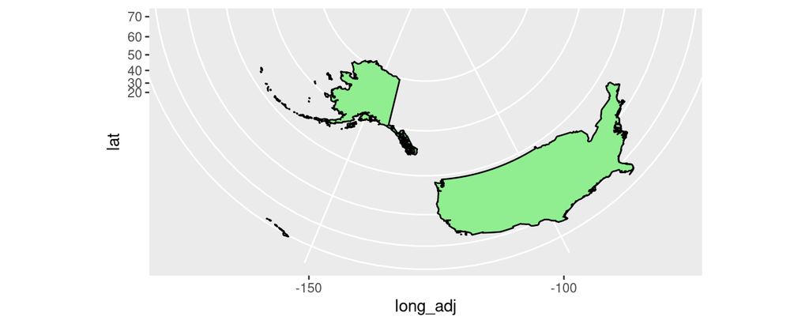

```r
worldmap + coord_map(projection = "ortho")
```

## Regions in `world_usa`

Notice we have both regions and subregions in this set.

```r
str(world_usa)
```

```
'data.frame':   5753 obs. of  6 variables:
 $ long     : num  -156 -156 -156 -156 -156 ...
 $ lat      : num  19 19 19 19.1 19.1 ...
 $ group    : num  1443 1443 1443 1443 1443 ...
 $ order    : int  91664 91665 91666 91667 91668 91669 91670 91671 91672 91673 ...
 $ region   : chr  "USA" "USA" "USA" "USA" ...
 $ subregion: chr  "Hawaii" "Hawaii" "Hawaii" "Hawaii" ...
```

## Region and Subregions

The count `n` is the number of coordinates for the subregion.

```r
tail(world_usa %>% count(region, subregion), 10)
```

```
   region       subregion    n
23    USA       Louisiana   28
24    USA           Maine   13
25    USA  Massachusettes   17
26    USA     Mississippi    7
27    USA        New York   53
28    USA Ocracoke Island    5
29    USA      Pea Island   13
30    USA           Texas   44
31    USA      Washington   55
32    USA            <NA> 1990
```

## Mapping Hawaii

In this dataset we filter for a US state using `subregion`.

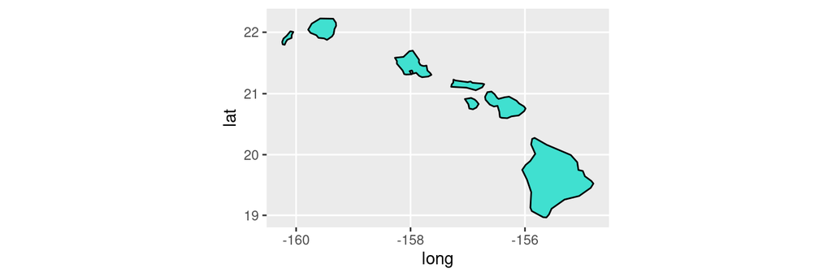

```r
filter(world_usa, subregion == "Hawaii") %>%
  ggplot() +
  geom_polygon(aes(x = long, y = lat, group = group),
               color = "black", fill = "turquoise") +
  coord_map()
```

## Removing the Axes

## Ditch the Axes!

We usually do not need the latitude and longitude axes on our maps, so we can use theme elements to get rid of them.

```r
# Theme Credit: http://eriqande.github.io/rep-res-web/lectures/
# making-maps-with-R.html (w/ the addition of panel.background)
# See also: https://ggplot2.tidyverse.org/reference/theme.html

ditch_the_axes <- theme(
  axis.title = element_blank(),
  axis.text = element_blank(),
  axis.line = element_blank(),
  axis.ticks = element_blank(),
  panel.border = element_blank(),
  panel.grid = element_blank(),
  panel.background = element_blank()
)
```

```r
ncmap <- filter(county, region == "north carolina") %>%
  ggplot() +
  geom_polygon(aes(x = long, y = lat, group = group),
               color = "black",
               fill = "lightgoldenrod")
```

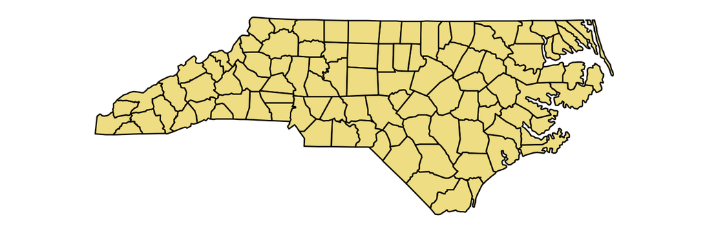

```r
ncmap +
  coord_map() +
  ditch_the_axes
```

## A More Elaborate Version

How is this similar to and different from the other version?

```r
no_axes_alt <- theme(
  panel.grid.major = element_line(colour = "transparent"),
  panel.grid.minor = element_blank(),
  axis.title.x = element_blank(),
  axis.text.x = element_blank(),
  axis.ticks.x = element_blank(),
  axis.title.y = element_blank(),
  axis.text.y = element_blank(),
  axis.ticks.y = element_blank(),
  panel.background = element_blank(),
  panel.border = element_blank(),
  plot.background = element_blank()
  )
```

## Another plot with no axes!

Again we use our stored map object and add customization.

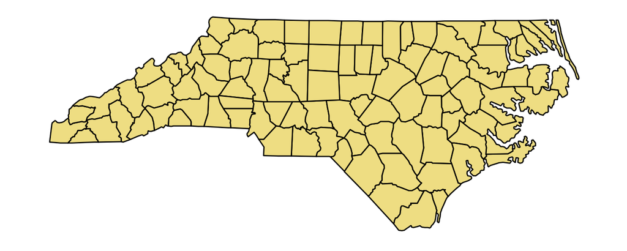

```r
ncmap +
  coord_map(projection = "mollweide") +
  no_axes_alt
```

## Plotting Data on a Map

## Boone on the NC Map

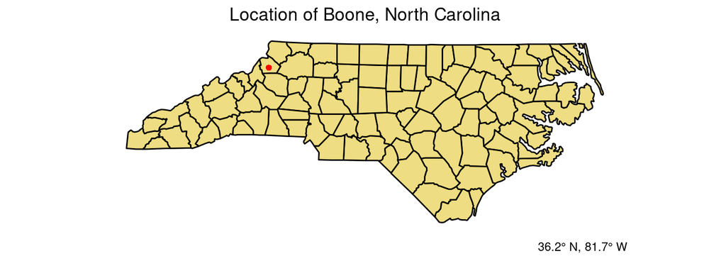

```r
ncmap +
  geom_point(aes(x = -81.7, y = 36.2), size = 1.25, color = "red") +
  coord_map() +
  labs(title = "Location of Boone, North Carolina",
       caption = "36.2° N, 81.7° W") +
  theme(plot.title = element_text(hjust = 0.5)) +
  ditch_the_axes
```

## Places Dr. Thomley Has Lived

```r
places = tibble(lats = c(41.6528, 42.3736, 42.6526, 36.2168),
                longs = c(-83.5379, -71.1097, -73.7562, -81.6746),
                names = c("Toledo", "Cambridge", "Albany", "Boone"))

ggplot() +
  geom_polygon(data = state, aes(x = long, y = lat, group = group),
               color = "white", fill = "thistle") +
  geom_point(data = places, aes(x = longs, y = lats),
             size = 2, shape = 8, color = "purple") +
  geom_label(data = places, aes(x = longs, y = lats, label = names),
             hjust = c("right", "right", "left", "right"),
             nudge_x = c(-1, -0.5, 0.5, -1),
             vjust = c("middle", "top", "bottom", "middle"),
             nudge_y = c(0, -0.5, 0.5, 0)) +
  coord_map() +
  ditch_the_axes
```

## The Map

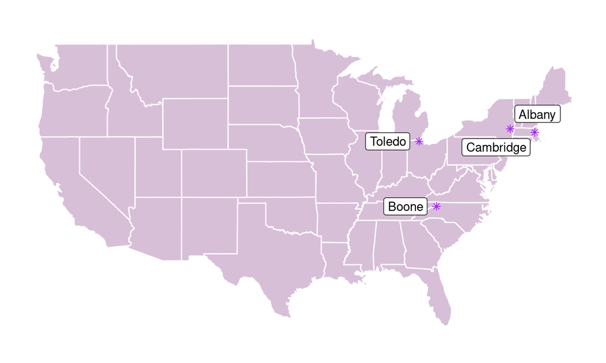

## References

- [Making Maps with R](http://eriqande.github.io/rep-res-web/lectures/making-maps-with-R.html)
- [Urban Mapper](https://github.com/UrbanInstitute/urbnmapr)
- [Draw Maps](https://socviz.co/maps.html)
- [DataCamp: Interactive Maps with leaflet in R](https://app.datacamp.com/learn/courses/interactive-maps-with-leaflet-in-r)
- [DataCamp: Visualizing Geospatial Data in R](https://app.datacamp.com/learn/courses/visualizing-geospatial-data-in-r)
- [DC Skill Track: Spatial Data with R](https://app.datacamp.com/learn/skill-tracks/spatial-data-with-r)